# Project Report :-

## Title : **Pawsitive Insights - Unleashing Data Science in Animal Shelters**

### Domain Area : Animal Welfare Organization

#### **Group Members**:

Adarsh Mahor  
Juily Pachundkar  
Kalp Mepani  
Manish Vankudre  
Mayuresh Dongare

1. Introduction
2. Project Objectives
3. Data Collection
4. Data Preprocessing
5. Exploratory Data Analysis (EDA)
6. Conclusion
7. Future Work

## 1. Introduction

- This project focuses on analyzing data from the Austin Animal Center.
- The primary objective is to use data science to improve the efficiency and effectiveness of the Austin Animal Center.
- The project aims to create a positive impact on both animal welfare and the shelter's overall operations.

## 2. Project Objectives

**Improve Adoption Rates:** - Increase the number of successful pet adoptions from the Austin Animal Center.

**Resource Optimization:** - Efficiently allocate resources, such as staff, kennels, and medical supplies, to improve shelter operations.

**Adoption Campaigns:** - Design targeted adoption campaigns based on data-driven insights to match pets with suitable adopters.

**Volunteer Programs:** - Align and optimize volunteer programs to support various shelter activities, such as pet care and adoption events.

**Data-Driven Decision-Making:** - Reduce or eliminate the problem of overpopulation and euthanasia in animal shelters through data-driven strategies and community engagement.

## 3. Data Collection

- Austin Animal Center Intakes  
  Link: https://data.austintexas.gov/Health-and-Community-Services/Austin-Animal-Center-Intakes/wter-evkm
- Austin Animal Center Outcomes  
  Link: https://data.austintexas.gov/Health-and-Community-Services/Austin-Animal-Center-Outcomes/9t4d-g238
- Austin Animal Center Stray Map  
  Link : https://data.austintexas.gov/dataset/Austin-Animal-Center-Stray-Map/kz4x-q9k5

```python
# Importing necessary libraries
import pandas as pd
import numpy as np
import matplotlib.pyplot as plt
import folium
```

```python
# importing "Austin Animal Center Intakes" csv file

df = pd.read_csv('Austin_Animal_Center_Intakes.csv')
df.head()
```

|  | Animal ID | Name | DateTime | MonthYear | Found Location | Intake Type | Intake Condition | Animal Type | Sex upon Intake | Age upon Intake | Breed | Color |
| --- | --- | --- | --- | --- | --- | --- | --- | --- | --- | --- | --- | --- |
| 0 | A786884 | *Brock | 01/03/2019 04:19:00 PM | January 2019 | 2501 Magin Meadow Dr in Austin (TX) | Stray | Normal | Dog | Neutered Male | 2 years | Beagle Mix | Tricolor |
| 1 | A706918 | Belle | 07/05/2015 12:59:00 PM | July 2015 | 9409 Bluegrass Dr in Austin (TX) | Stray | Normal | Dog | Spayed Female | 8 years | English Springer Spaniel | White/Liver |
| 2 | A724273 | Runster | 04/14/2016 06:43:00 PM | April 2016 | 2818 Palomino Trail in Austin (TX) | Stray | Normal | Dog | Intact Male | 11 months | Basenji Mix | Sable/White |
| 3 | A857105 | Johnny Ringo | 05/12/2022 12:23:00 AM | May 2022 | 4404 Sarasota Drive in Austin (TX) | Public Assist | Normal | Cat | Neutered Male | 2 years | Domestic Shorthair | Orange Tabby |
| 4 | A682524 | Rio | 06/29/2014 10:38:00 AM | June 2014 | 800 Grove Blvd in Austin (TX) | Stray | Normal | Dog | Neutered Male | 4 years | Doberman Pinsch/Australian Cattle Dog | Tan/Gray |

```python
# importing "Austin_Animal_Center_Outcomes" csv file

df2 = pd.read_csv('Austin_Animal_Center_Outcomes.csv')
df2.head()
```

|  | Animal ID | Name | DateTime | MonthYear | Date of Birth | Outcome Type | Outcome Subtype | Animal Type | Sex upon Outcome | Age upon Outcome | Breed | Color |
| --- | --- | --- | --- | --- | --- | --- | --- | --- | --- | --- | --- | --- |
| 0 | A794011 | Chunk | 05/08/2019 06:20:00 PM | May 2019 | 05/02/2017 | Rto-Adopt | NaN | Cat | Neutered Male | 2 years | Domestic Shorthair Mix | Brown Tabby/White |
| 1 | A776359 | Gizmo | 07/18/2018 04:02:00 PM | Jul 2018 | 07/12/2017 | Adoption | NaN | Dog | Neutered Male | 1 year | Chihuahua Shorthair Mix | White/Brown |
| 2 | A821648 | NaN | 08/16/2020 11:38:00 AM | Aug 2020 | 08/16/2019 | Euthanasia | NaN | Other | Unknown | 1 year | Raccoon | Gray |
| 3 | A720371 | Moose | 02/13/2016 05:59:00 PM | Feb 2016 | 10/08/2015 | Adoption | NaN | Dog | Neutered Male | 4 months | Anatol Shepherd/Labrador Retriever | Buff |
| 4 | A674754 | NaN | 03/18/2014 11:47:00 AM | Mar 2014 | 03/12/2014 | Transfer | Partner | Cat | Intact Male | 6 days | Domestic Shorthair Mix | Orange Tabby |

```python
# Austin_Animal_Center_Stray_Map
df_map = pd.read_csv("Austin_Animal_Center_Stray_Map.csv")
```

```python
df_map.head()
```

|  | Animal ID | Found Location | At AAC | Intake Date | Type | Looks Like | Color | Sex | Age | Image Link | Single Member Council Districts | BOUNDARIES_single_member_districts | Neighborhood Planning Areas | Community Registry | Zipcodes | Zoning Review Cases_data | Zip Codes | Austin Police Sectors | Green Building Mandatory |
| --- | --- | --- | --- | --- | --- | --- | --- | --- | --- | --- | --- | --- | --- | --- | --- | --- | --- | --- | --- |
| 0 | A878668 | CONGRESS\nAUSTIN 78745 | No (contact for more info) | 04/14/2023 | Cat | Domestic Shorthair | Tortie | Intact Female | 2 years | http://www.petharbor.com/pet.asp?uaid=ASTN.A87... | NaN | NaN | NaN | NaN | NaN | NaN | NaN | NaN | NaN |
| 1 | A878853 | 5408 WESTMINSTER DRIVE\nAUSTIN 78723\n(30.3066... | Yes (come to the shelter) | 04/18/2023 | Dog | Pit Bull Mix | Blue/White | Intact Female | 7 months | http://www.petharbor.com/pet.asp?uaid=ASTN.A87... | 4.0 | 9.0 | 84.0 | 309.0 | 33.0 | NaN | 3239.0 | 38.0 | NaN |
| 2 | A879012 | 5005 BUFFALO PASS\nAUSTIN 78745\n(30.22331, -9... | No (contact for more info) | 04/20/2023 | Cat | Domestic Shorthair | Orange Tabby | Intact Female | 6 weeks | http://www.petharbor.com/pet.asp?uaid=ASTN.A87... | 5.0 | 1.0 | 92.0 | 373.0 | 23.0 | 3819.0 | 3259.0 | 52.0 | NaN |
| 3 | A682044 | JAKES HILL78660 | Yes (come to the shelter) | 04/18/2023 | Cat | Domestic Shorthair Mix | Calico | Spayed Female | 8 years | http://www.petharbor.com/pet.asp?uaid=ASTN.A68... | NaN | NaN | NaN | NaN | NaN | NaN | NaN | NaN | NaN |
| 4 | A878939 | EMERALD FOREST\nAUSTIN 78745 | Yes (come to the shelter) | 04/19/2023 | Cat | Domestic Shorthair | Brown Tabby | Intact Male | 1 year | http://www.petharbor.com/pet.asp?uaid=ASTN.A87... | NaN | NaN | NaN | NaN | NaN | NaN | NaN | NaN | NaN |

## 4. Data Preprocessing

- In this section, we'll detail the steps taken to prepare the raw data for analysis. Data preprocessing is a crucial phase in any data science project as it ensures that the data is clean, consistent, and ready for further exploration and modeling.

```python
# Austin Animal Center Intakes
df.shape
```

```
(155651, 12)
```

```python
df.info()
```

```
<class 'pandas.core.frame.DataFrame'>
RangeIndex: 155651 entries, 0 to 155650
Data columns (total 12 columns):
 #   Column            Non-Null Count   Dtype
---  ------            --------------   -----
 0   Animal ID         155651 non-null  object
 1   Name              110770 non-null  object
 2   DateTime          155651 non-null  object
 3   MonthYear         155651 non-null  object
 4   Found Location    155651 non-null  object
 5   Intake Type       155651 non-null  object
 6   Intake Condition  155651 non-null  object
 7   Animal Type       155651 non-null  object
 8   Sex upon Intake   155649 non-null  object
 9   Age upon Intake   155650 non-null  object
 10  Breed             155651 non-null  object
 11  Color             155651 non-null  object
dtypes: object(12)
memory usage: 14.3+ MB
```

```python
df['Name'].fillna('No_Name', inplace=True)
```

```python
duplicate_rows_df = df[df.duplicated()]
print("number of duplicate rows : ",duplicate_rows_df.shape)
```

```
number of duplicate rows :  (29, 12)
```

```python
df.dropna(inplace=True)
```

```python
df.count()
```

```
Animal ID           155649
Name                155649
DateTime            155649
MonthYear           155649
Found Location      155649
Intake Type         155649
Intake Condition    155649
Animal Type         155649
Sex upon Intake     155649
Age upon Intake     155649
Breed               155649
Color               155649
dtype: int64
```

```python
# Austin_Animal_Center_Outcomes
df2.info()
```

```
<class 'pandas.core.frame.DataFrame'>
RangeIndex: 155506 entries, 0 to 155505
Data columns (total 12 columns):
 #   Column            Non-Null Count   Dtype
---  ------            --------------   -----
 0   Animal ID         155506 non-null  object
 1   Name              110757 non-null  object
 2   DateTime          155506 non-null  object
 3   MonthYear         155506 non-null  object
 4   Date of Birth     155506 non-null  object
 5   Outcome Type      155476 non-null  object
 6   Outcome Subtype   71696 non-null   object
 7   Animal Type       155506 non-null  object
 8   Sex upon Outcome  155504 non-null  object
 9   Age upon Outcome  155465 non-null  object
 10  Breed             155506 non-null  object
 11  Color             155506 non-null  object
dtypes: object(12)
memory usage: 14.2+ MB
```

```python
df2.shape

duplicate_rows_df2 = df2[df2.duplicated()]
print("number of duplicate rows : ",duplicate_rows_df2.shape)
```

```
number of duplicate rows :  (22, 12)
```

```python
df2.count()
```

```
Animal ID           155506
Name                110757
DateTime            155506
MonthYear           155506
Date of Birth       155506
Outcome Type        155476
Outcome Subtype      71696
Animal Type         155506
Sex upon Outcome    155504
Age upon Outcome    155465
Breed               155506
Color               155506
dtype: int64
```

```python
missing_values = df2.isnull().sum()
print(missing_values)
```

```
Animal ID               0
Name                44749
DateTime                0
MonthYear               0
Date of Birth           0
Outcome Type           30
Outcome Subtype     83810
Animal Type             0
Sex upon Outcome        2
Age upon Outcome       41
Breed                   0
Color                   0
dtype: int64
```

```python
df2['Sex upon Outcome'].fillna('Unknown', inplace=True)
df2['Outcome Subtype'].fillna('Unknown', inplace=True)
df2['Name'].fillna('Unknown', inplace=True)
df2['Age upon Outcome'].fillna('Unknown', inplace=True)
df2['Outcome Type'].fillna('Unknown', inplace=True)
```

```python
df2.count()
```

```
Animal ID           155506
Name                155506
DateTime            155506
MonthYear           155506
Date of Birth       155506
Outcome Type        155506
Outcome Subtype     155506
Animal Type         155506
Sex upon Outcome    155506
Age upon Outcome    155506
Breed               155506
Color               155506
dtype: int64
```

```python
df2.columns
```

```
Index(['Animal ID', 'Name', 'DateTime', 'MonthYear', 'Date of Birth',
       'Outcome Type', 'Outcome Subtype', 'Animal Type', 'Sex upon Outcome',
       'Age upon Outcome', 'Breed', 'Color'],
      dtype='object')
```

```python
df2.head()
```

|  | Animal ID | Name | DateTime | MonthYear | Date of Birth | Outcome Type | Outcome Subtype | Animal Type | Sex upon Outcome | Age upon Outcome | Breed | Color |
| --- | --- | --- | --- | --- | --- | --- | --- | --- | --- | --- | --- | --- |
| 0 | A794011 | Chunk | 05/08/2019 06:20:00 PM | May 2019 | 05/02/2017 | Rto-Adopt | Unknown | Cat | Neutered Male | 2 years | Domestic Shorthair Mix | Brown Tabby/White |
| 1 | A776359 | Gizmo | 07/18/2018 04:02:00 PM | Jul 2018 | 07/12/2017 | Adoption | Unknown | Dog | Neutered Male | 1 year | Chihuahua Shorthair Mix | White/Brown |
| 2 | A821648 | Unknown | 08/16/2020 11:38:00 AM | Aug 2020 | 08/16/2019 | Euthanasia | Unknown | Other | Unknown | 1 year | Raccoon | Gray |
| 3 | A720371 | Moose | 02/13/2016 05:59:00 PM | Feb 2016 | 10/08/2015 | Adoption | Unknown | Dog | Neutered Male | 4 months | Anatol Shepherd/Labrador Retriever | Buff |
| 4 | A674754 | Unknown | 03/18/2014 11:47:00 AM | Mar 2014 | 03/12/2014 | Transfer | Partner | Cat | Intact Male | 6 days | Domestic Shorthair Mix | Orange Tabby |

```python
df2.columns
```

```
Index(['Animal ID', 'Name', 'DateTime', 'MonthYear', 'Date of Birth',
       'Outcome Type', 'Outcome Subtype', 'Animal Type', 'Sex upon Outcome',
       'Age upon Outcome', 'Breed', 'Color'],
      dtype='object')
```

```python
df2.count()
```

```
Animal ID           155506
Name                155506
DateTime            155506
MonthYear           155506
Date of Birth       155506
Outcome Type        155506
Outcome Subtype     155506
Animal Type         155506
Sex upon Outcome    155506
Age upon Outcome    155506
Breed               155506
Color               155506
dtype: int64
```

```python
df2['Age upon Outcome'].head()
```

```
0     2 years
1      1 year
2      1 year
3    4 months
4      6 days
Name: Age upon Outcome, dtype: object
```

In the below code snippet, we are performing data transformation on a column called 'Age upon Outcome' in a DataFrame called 'df2.' The objective is to convert age values in various units (years, months, weeks, days) into a consistent format of age in days for analysis.

```python
import re
# Define a function to convert age to days
def age_to_days(age_str):
    if isinstance(age_str, str):  # Check if the input is a string
        # Extract numeric value and unit using regular expressions
        match = re.match(r'(\d+)\s+(\w+)', age_str)
        if match:
            age, unit = match.groups()
            age = int(age)
            if unit == 'year' or unit == 'years':
                return age * 365  # Assuming 1 year = 365 days
            elif unit == 'month' or unit == 'months':
                return age * 30  # Assuming 1 month = 30 days
            elif unit == 'week' or unit == 'weeks':
                return age * 7
            elif unit == 'day' or unit == 'days':
                return age
    return None  # Return None for invalid data or non-string input

# Apply the function to the entire column and create a new column with age in days
df2['Age upon Outcome (days)'] = df2['Age upon Outcome'].apply(age_to_days)

# Print the result
print(df2[['Age upon Outcome', 'Age upon Outcome (days)']])
```

```
       Age upon Outcome  Age upon Outcome (days)
0               2 years                    730.0
1                1 year                    365.0
2                1 year                    365.0
3              4 months                    120.0
4                6 days                      6.0
...                 ...                      ...
155501          0 years                      0.0
155502          0 years                      0.0
155503         2 months                     60.0
155504          2 years                    730.0
155505          9 years                   3285.0

[155506 rows x 2 columns]
```

```python
df2['Age upon Outcome'].fillna('Unknown', inplace=True)
```

```python
df2.columns
```

```
Index(['Animal ID', 'Name', 'DateTime', 'MonthYear', 'Date of Birth',
       'Outcome Type', 'Outcome Subtype', 'Animal Type', 'Sex upon Outcome',
       'Age upon Outcome', 'Breed', 'Color', 'Age upon Outcome (days)'],
      dtype='object')
```

```python
df2.head()
```

|  | Animal ID | Name | DateTime | MonthYear | Date of Birth | Outcome Type | Outcome Subtype | Animal Type | Sex upon Outcome | Age upon Outcome | Breed | Color | Age upon Outcome (days) |
| --- | --- | --- | --- | --- | --- | --- | --- | --- | --- | --- | --- | --- | --- |
| 0 | A794011 | Chunk | 05/08/2019 06:20:00 PM | May 2019 | 05/02/2017 | Rto-Adopt | Unknown | Cat | Neutered Male | 2 years | Domestic Shorthair Mix | Brown Tabby/White | 730.0 |
| 1 | A776359 | Gizmo | 07/18/2018 04:02:00 PM | Jul 2018 | 07/12/2017 | Adoption | Unknown | Dog | Neutered Male | 1 year | Chihuahua Shorthair Mix | White/Brown | 365.0 |
| 2 | A821648 | Unknown | 08/16/2020 11:38:00 AM | Aug 2020 | 08/16/2019 | Euthanasia | Unknown | Other | Unknown | 1 year | Raccoon | Gray | 365.0 |
| 3 | A720371 | Moose | 02/13/2016 05:59:00 PM | Feb 2016 | 10/08/2015 | Adoption | Unknown | Dog | Neutered Male | 4 months | Anatol Shepherd/Labrador Retriever | Buff | 120.0 |
| 4 | A674754 | Unknown | 03/18/2014 11:47:00 AM | Mar 2014 | 03/12/2014 | Transfer | Partner | Cat | Intact Male | 6 days | Domestic Shorthair Mix | Orange Tabby | 6.0 |

```python
# This line of code converts the 'DateTime','MonthYear' , 'Date of Birth' column in our dataset to a consistent datetime format.

df2['DateTime'] = pd.to_datetime(df2['DateTime'])
df2['MonthYear'] = pd.to_datetime(df2['MonthYear'])
df2['Date of Birth'] = pd.to_datetime(df2['Date of Birth'])
```

```
C:\Users\Manish Vankudre\AppData\Local\Temp\ipykernel_5932\1393645379.py:3: UserWarning: Could not infer format, so each element will be parsed individually, falling back to `dateutil`. To ensure parsing is consistent and as-expected, please specify a format.
  df2['DateTime'] = pd.to_datetime(df2['DateTime'])
C:\Users\Manish Vankudre\AppData\Local\Temp\ipykernel_5932\1393645379.py:4: UserWarning: Could not infer format, so each element will be parsed individually, falling back to `dateutil`. To ensure parsing is consistent and as-expected, please specify a format.
  df2['MonthYear'] = pd.to_datetime(df2['MonthYear'])
```

```python
df2.drop(columns=['Age upon Outcome'], inplace=True)
```

In below cell we are renaming the column names in our dataset to make them more descriptive and user-friendly. This step is crucial for enhancing the clarity and readability of our data for analysis and reporting purposes.

```python
df2.rename(columns={
    'Animal ID': 'Animal_ID',
    'Outcome Type': 'Outcome_Type',
    'Outcome Subtype': 'Outcome_Subtype',
    'Animal Type': 'Animal_Type',
    'Sex upon Outcome': 'Sex_upon_Outcome',
    'Breed': 'Breed',
    'Color': 'Color',
    'Age upon Outcome (days)' : 'Age_upon_Outcome',
    'Date of Birth' :'Date_of_Birth'
}, inplace=True)
```

```python
df2.head()
```

|  | Animal_ID | Name | DateTime | MonthYear | Date_of_Birth | Outcome_Type | Outcome_Subtype | Animal_Type | Sex_upon_Outcome | Breed | Color | Age_upon_Outcome |
| --- | --- | --- | --- | --- | --- | --- | --- | --- | --- | --- | --- | --- |
| 0 | A794011 | Chunk | 2019-05-08 18:20:00 | 2019-05-01 | 2017-05-02 | Rto-Adopt | Unknown | Cat | Neutered Male | Domestic Shorthair Mix | Brown Tabby/White | 730.0 |
| 1 | A776359 | Gizmo | 2018-07-18 16:02:00 | 2018-07-01 | 2017-07-12 | Adoption | Unknown | Dog | Neutered Male | Chihuahua Shorthair Mix | White/Brown | 365.0 |
| 2 | A821648 | Unknown | 2020-08-16 11:38:00 | 2020-08-01 | 2019-08-16 | Euthanasia | Unknown | Other | Unknown | Raccoon | Gray | 365.0 |
| 3 | A720371 | Moose | 2016-02-13 17:59:00 | 2016-02-01 | 2015-10-08 | Adoption | Unknown | Dog | Neutered Male | Anatol Shepherd/Labrador Retriever | Buff | 120.0 |
| 4 | A674754 | Unknown | 2014-03-18 11:47:00 | 2014-03-01 | 2014-03-12 | Transfer | Partner | Cat | Intact Male | Domestic Shorthair Mix | Orange Tabby | 6.0 |

```python
df2.columns
```

```
Index(['Animal_ID', 'Name', 'DateTime', 'MonthYear', 'Date_of_Birth',
       'Outcome_Type', 'Outcome_Subtype', 'Animal_Type', 'Sex_upon_Outcome',
       'Breed', 'Color', 'Age_upon_Outcome'],
      dtype='object')
```

```python
df.columns
```

```
Index(['Animal ID', 'Name', 'DateTime', 'MonthYear', 'Found Location',
       'Intake Type', 'Intake Condition', 'Animal Type', 'Sex upon Intake',
       'Age upon Intake', 'Breed', 'Color'],
      dtype='object')
```

```python
df['Age upon Intake (days)'] = df['Age upon Intake'].apply(age_to_days)
```

```python
df.head()
```

|  | Animal ID | Name | DateTime | MonthYear | Found Location | Intake Type | Intake Condition | Animal Type | Sex upon Intake | Age upon Intake | Breed | Color | Age upon Intake (days) |
| --- | --- | --- | --- | --- | --- | --- | --- | --- | --- | --- | --- | --- | --- |
| 0 | A786884 | *Brock | 01/03/2019 04:19:00 PM | January 2019 | 2501 Magin Meadow Dr in Austin (TX) | Stray | Normal | Dog | Neutered Male | 2 years | Beagle Mix | Tricolor | 730.0 |
| 1 | A706918 | Belle | 07/05/2015 12:59:00 PM | July 2015 | 9409 Bluegrass Dr in Austin (TX) | Stray | Normal | Dog | Spayed Female | 8 years | English Springer Spaniel | White/Liver | 2920.0 |
| 2 | A724273 | Runster | 04/14/2016 06:43:00 PM | April 2016 | 2818 Palomino Trail in Austin (TX) | Stray | Normal | Dog | Intact Male | 11 months | Basenji Mix | Sable/White | 330.0 |
| 3 | A857105 | Johnny Ringo | 05/12/2022 12:23:00 AM | May 2022 | 4404 Sarasota Drive in Austin (TX) | Public Assist | Normal | Cat | Neutered Male | 2 years | Domestic Shorthair | Orange Tabby | 730.0 |
| 4 | A682524 | Rio | 06/29/2014 10:38:00 AM | June 2014 | 800 Grove Blvd in Austin (TX) | Stray | Normal | Dog | Neutered Male | 4 years | Doberman Pinsch/Australian Cattle Dog | Tan/Gray | 1460.0 |

```python
df['Age upon Intake (days)'] = df['Age upon Intake (days)'].apply(lambda x: abs(x))
```

```python
column_name_mapping = {
    'Animal ID': 'ID',
    'Name': 'Pet_Name',
    'DateTime': 'Intake_DateTime',
    'MonthYear': 'Intake_MonthYear',
    'Found Location': 'Intake_Location',
    'Intake Type': 'Type_of_Intake',
    'Intake Condition': 'Condition_at_Intake',
    'Animal Type': 'Pet_Type',
    'Sex upon Intake': 'Sex_at_Intake',
    'Age upon Intake': 'Age_at_Intake',
    'Breed': 'Pet_Breed',
    'Color': 'Pet_Color',
    'Age upon Intake (days)': 'Age_at_Intake_in_Days'
}
df.rename(columns=column_name_mapping, inplace=True)
```

```python
df['Intake_DateTime'] = pd.to_datetime(df['Intake_DateTime'])
df['Intake_MonthYear'] = pd.to_datetime(df['Intake_MonthYear'])
```

```
C:\Users\Manish Vankudre\AppData\Local\Temp\ipykernel_5932\2495505847.py:1: UserWarning: Could not infer format, so each element will be parsed individually, falling back to `dateutil`. To ensure parsing is consistent and as-expected, please specify a format.
  df['Intake_DateTime'] = pd.to_datetime(df['Intake_DateTime'])
C:\Users\Manish Vankudre\AppData\Local\Temp\ipykernel_5932\2495505847.py:2: UserWarning: Could not infer format, so each element will be parsed individually, falling back to `dateutil`. To ensure parsing is consistent and as-expected, please specify a format.
  df['Intake_MonthYear'] = pd.to_datetime(df['Intake_MonthYear'])
```

```python
print(df.dtypes)
print(df.columns)
```

```
ID                               object
Pet_Name                         object
Intake_DateTime          datetime64[ns]
Intake_MonthYear         datetime64[ns]
Intake_Location                  object
Type_of_Intake                   object
Condition_at_Intake              object
Pet_Type                         object
Sex_at_Intake                    object
Age_at_Intake                    object
Pet_Breed                        object
Pet_Color                        object
Age_at_Intake_in_Days           float64
dtype: object
Index(['ID', 'Pet_Name', 'Intake_DateTime', 'Intake_MonthYear',
       'Intake_Location', 'Type_of_Intake', 'Condition_at_Intake', 'Pet_Type',
       'Sex_at_Intake', 'Age_at_Intake', 'Pet_Breed', 'Pet_Color',
       'Age_at_Intake_in_Days'],
      dtype='object')
```

```python
print(df2.dtypes)
print(df2.columns)
```

```
Animal_ID                   object
Name                        object
DateTime            datetime64[ns]
MonthYear           datetime64[ns]
Date_of_Birth       datetime64[ns]
Outcome_Type                object
Outcome_Subtype             object
Animal_Type                 object
Sex_upon_Outcome            object
Breed                       object
Color                       object
Age_upon_Outcome           float64
dtype: object
Index(['Animal_ID', 'Name', 'DateTime', 'MonthYear', 'Date_of_Birth',
       'Outcome_Type', 'Outcome_Subtype', 'Animal_Type', 'Sex_upon_Outcome',
       'Breed', 'Color', 'Age_upon_Outcome'],
      dtype='object')
```

```python
# Austin_Animal_Center_Stray_Map
df_map.head()
```

|  | Animal ID | Found Location | At AAC | Intake Date | Type | Looks Like | Color | Sex | Age | Image Link | Single Member Council Districts | BOUNDARIES_single_member_districts | Neighborhood Planning Areas | Community Registry | Zipcodes | Zoning Review Cases_data | Zip Codes | Austin Police Sectors | Green Building Mandatory |
| --- | --- | --- | --- | --- | --- | --- | --- | --- | --- | --- | --- | --- | --- | --- | --- | --- | --- | --- | --- |
| 0 | A878668 | CONGRESS\nAUSTIN 78745 | No (contact for more info) | 04/14/2023 | Cat | Domestic Shorthair | Tortie | Intact Female | 2 years | http://www.petharbor.com/pet.asp?uaid=ASTN.A87... | NaN | NaN | NaN | NaN | NaN | NaN | NaN | NaN | NaN |
| 1 | A878853 | 5408 WESTMINSTER DRIVE\nAUSTIN 78723\n(30.3066... | Yes (come to the shelter) | 04/18/2023 | Dog | Pit Bull Mix | Blue/White | Intact Female | 7 months | http://www.petharbor.com/pet.asp?uaid=ASTN.A87... | 4.0 | 9.0 | 84.0 | 309.0 | 33.0 | NaN | 3239.0 | 38.0 | NaN |
| 2 | A879012 | 5005 BUFFALO PASS\nAUSTIN 78745\n(30.22331, -9... | No (contact for more info) | 04/20/2023 | Cat | Domestic Shorthair | Orange Tabby | Intact Female | 6 weeks | http://www.petharbor.com/pet.asp?uaid=ASTN.A87... | 5.0 | 1.0 | 92.0 | 373.0 | 23.0 | 3819.0 | 3259.0 | 52.0 | NaN |
| 3 | A682044 | JAKES HILL78660 | Yes (come to the shelter) | 04/18/2023 | Cat | Domestic Shorthair Mix | Calico | Spayed Female | 8 years | http://www.petharbor.com/pet.asp?uaid=ASTN.A68... | NaN | NaN | NaN | NaN | NaN | NaN | NaN | NaN | NaN |
| 4 | A878939 | EMERALD FOREST\nAUSTIN 78745 | Yes (come to the shelter) | 04/19/2023 | Cat | Domestic Shorthair | Brown Tabby | Intact Male | 1 year | http://www.petharbor.com/pet.asp?uaid=ASTN.A87... | NaN | NaN | NaN | NaN | NaN | NaN | NaN | NaN | NaN |

```python
df_map.info()
```

```
<class 'pandas.core.frame.DataFrame'>
RangeIndex: 124 entries, 0 to 123
Data columns (total 19 columns):
 #   Column                              Non-Null Count  Dtype
---  ------                              --------------  -----
 0   Animal ID                           124 non-null    object
 1   Found Location                      124 non-null    object
 2   At AAC                              124 non-null    object
 3   Intake Date                         124 non-null    object
 4   Type                                124 non-null    object
 5   Looks Like                          124 non-null    object
 6   Color                               124 non-null    object
 7   Sex                                 124 non-null    object
 8   Age                                 124 non-null    object
 9   Image Link                          124 non-null    object
 10  Single Member Council Districts     66 non-null     float64
 11  BOUNDARIES_single_member_districts  66 non-null     float64
 12  Neighborhood Planning Areas         49 non-null     float64
 13  Community Registry                  84 non-null     float64
 14  Zipcodes                            84 non-null     float64
 15  Zoning Review Cases_data            36 non-null     float64
 16  Zip Codes                           89 non-null     float64
 17  Austin Police Sectors               64 non-null     float64
 18  Green Building Mandatory            0 non-null      float64
dtypes: float64(9), object(10)
memory usage: 18.5+ KB
```

```python
# Extract latitude and longitude using regular expressions
df_map[['Latitude', 'Longitude']] = df_map['Found Location'].str.extract(r'\(([^,]+), ([^)]+)\)', expand=True)

# Convert latitude and longitude columns to numeric (float) type
df_map['Latitude'] = pd.to_numeric(df_map['Latitude'], errors='coerce')
df_map['Longitude'] = pd.to_numeric(df_map['Longitude'], errors='coerce')
```

```python
# Drop rows with NaN values in the 'Latitude' and 'Longitude' columns
df_map.dropna(subset=['Latitude', 'Longitude'], inplace=True)

# Reset the DataFrame index after dropping rows
df_map.reset_index(drop=True, inplace=True)
```

## 5. Exploratory Data Analysis (EDA)

[figure not shown]

```python
# Group the data by month and year and count the number of adoptions in each month
adoption_trends = df.groupby(df['Intake_DateTime'].dt.to_period('M'))['ID'].count()

# Converting the Period index to strings in the format 'YYYY-MM' for labeling
adoption_trends.index = adoption_trends.index.strftime('%Y-%m')

# Creating a line chart to visualize adoption trends over time
plt.figure(figsize=(10, 6))
plt.plot(adoption_trends.index, adoption_trends.values, marker='o', linestyle='-')
plt.title('Adoption Trends Over Time')
plt.xlabel('Month-Year')
plt.ylabel('Number of Adoptions')

# Set the frequency of x-axis ticks to display every n months (adjust n as needed)
n = 6
plt.xticks(adoption_trends.index[::n], rotation=45)

# Displaying the chart
plt.tight_layout()
plt.show()
```

### Intakes Types BreakDown

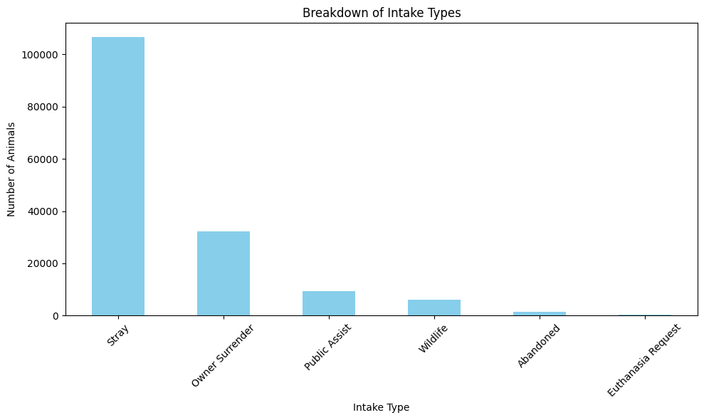

```python
# Count the number of animals for each intake type
intake_type_counts = df['Type_of_Intake'].value_counts()

# Create a bar chart to visualize the breakdown of intake types
plt.figure(figsize=(10, 6))
intake_type_counts.plot(kind='bar', color='skyblue')
plt.title('Breakdown of Intake Types')
plt.xlabel('Intake Type')
plt.ylabel('Number of Animals')
plt.xticks(rotation=45)  # Rotate x-axis labels for better readability

# Show the chart
plt.tight_layout()
plt.show()
```

### Intakes Trend Over Time

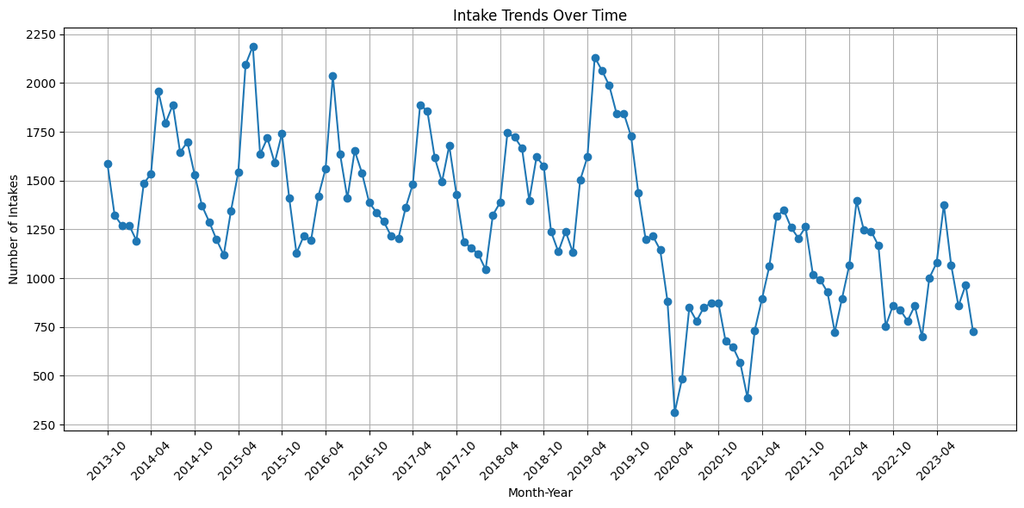

```python
import pandas as pd
import matplotlib.pyplot as plt


intake_trends = df.groupby(df['Intake_DateTime'].dt.to_period('M'))['ID'].count()

intake_trends.index = intake_trends.index.strftime('%Y-%m')

plt.figure(figsize=(12, 6))
plt.plot(intake_trends.index, intake_trends.values, marker='o', linestyle='-')
plt.title('Intake Trends Over Time')
plt.xlabel('Month-Year')
plt.ylabel('Number of Intakes')


plt.xticks(range(0, len(intake_trends.index), 6), intake_trends.index[::6], rotation=45)

plt.grid(True)

plt.tight_layout()
plt.show()
```

### Outcomes Trend Over Time

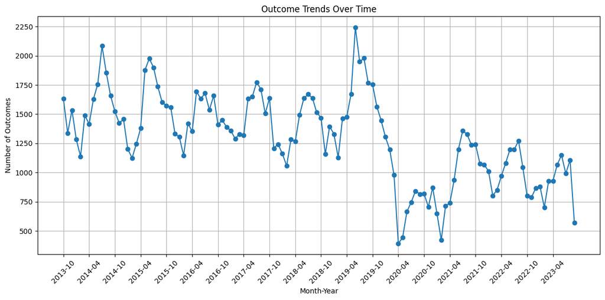

```python
outcome_trends = df2.groupby(df2['DateTime'].dt.to_period('M'))['Animal_ID'].count()
outcome_trends.index = outcome_trends.index.strftime('%Y-%m')

plt.figure(figsize=(12, 6))
plt.plot(outcome_trends.index, outcome_trends.values, marker='o', linestyle='-')
plt.title('Outcome Trends Over Time')
plt.xlabel('Month-Year')
plt.ylabel('Number of Outcomes')

plt.xticks(range(0, len(outcome_trends.index), 6), outcome_trends.index[::6], rotation=45)

plt.grid(True)

plt.tight_layout()
plt.show()
```

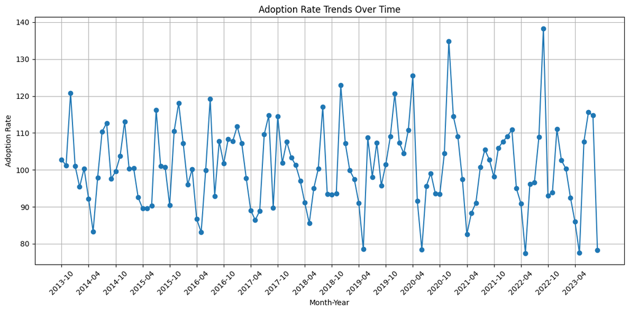

```python
intake_trends = df.groupby(df['Intake_DateTime'].dt.to_period('M'))['ID'].count()
outcome_trends = df2.groupby(df2['DateTime'].dt.to_period('M'))['Animal_ID'].count()

intake_trends.index = intake_trends.index.strftime('%Y-%m')
outcome_trends.index = outcome_trends.index.strftime('%Y-%m')

adoption_rate = (outcome_trends / intake_trends).fillna(0)*100

plt.figure(figsize=(12, 6))
plt.plot(adoption_rate.index, adoption_rate.values, marker='o', linestyle='-')
plt.title('Adoption Rate Trends Over Time')
plt.xlabel('Month-Year')
plt.ylabel('Adoption Rate')
plt.xticks(range(0, len(adoption_rate.index), 6), adoption_rate.index[::6], rotation=45)
plt.grid(True)

plt.tight_layout()
plt.show()
```

### Intake and Outcome Trends Over Time

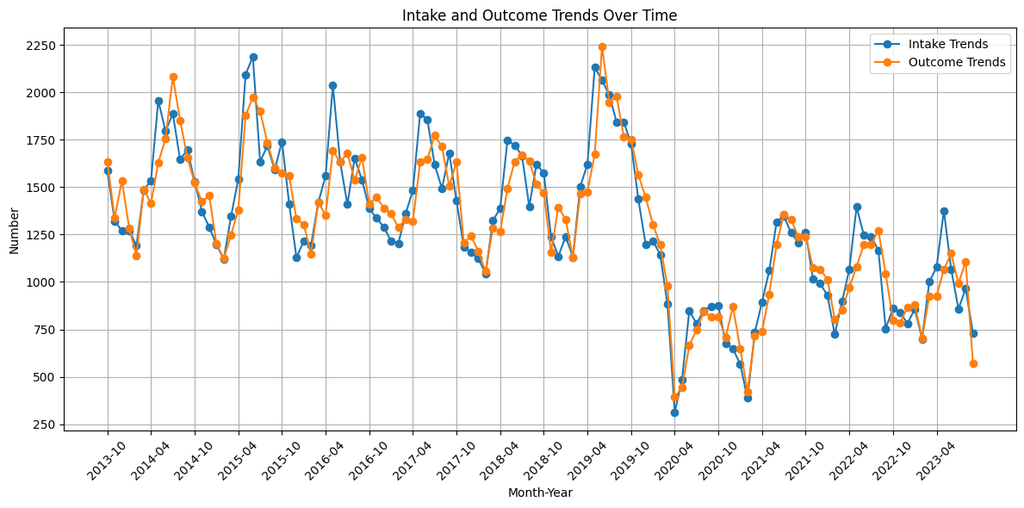

```python
intake_trends = df.groupby(df['Intake_DateTime'].dt.to_period('M'))['ID'].count()
outcome_trends = df2.groupby(df2['DateTime'].dt.to_period('M'))['Animal_ID'].count()

intake_trends.index = intake_trends.index.strftime('%Y-%m')
outcome_trends.index = outcome_trends.index.strftime('%Y-%m')

plt.figure(figsize=(12, 6))
plt.plot(intake_trends.index, intake_trends.values, marker='o', linestyle='-', label='Intake Trends')
plt.plot(outcome_trends.index, outcome_trends.values, marker='o', linestyle='-', label='Outcome Trends')
plt.title('Intake and Outcome Trends Over Time')
plt.xlabel('Month-Year')
plt.ylabel('Number')
plt.legend()

plt.xticks(range(0, len(intake_trends.index), 6), intake_trends.index[::6], rotation=45)

plt.grid(True)

plt.tight_layout()
plt.show()
```

### Top 10 Popular Adopted Breeds

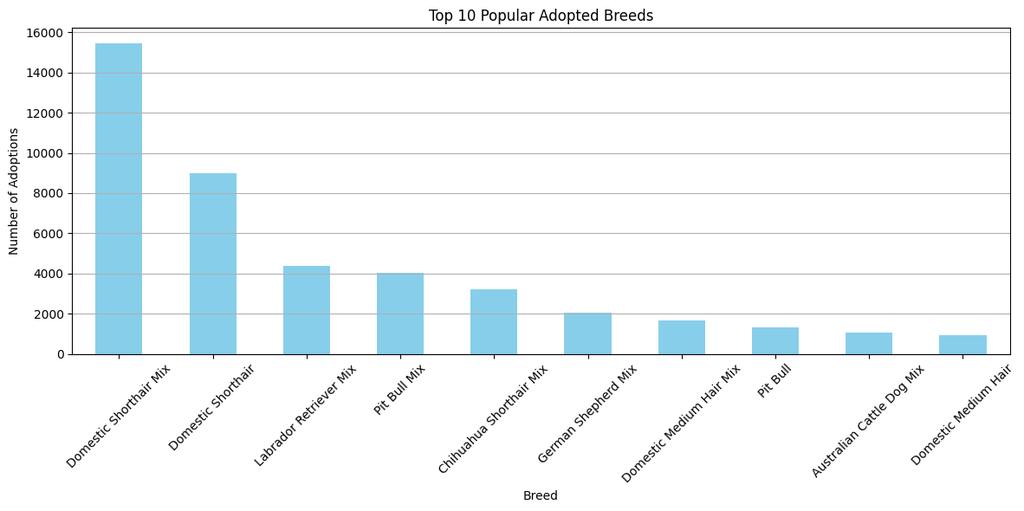

```python
import pandas as pd
import matplotlib.pyplot as plt

# Group the outcome data by breed and count the number of adoptions for each breed
breed_adoption_counts = df2[df2['Outcome_Type'] == 'Adoption'].groupby('Breed')['Animal_ID'].count()

# Sort the breeds by adoption count in descending order to find the most popular breeds
popular_breeds = breed_adoption_counts.sort_values(ascending=False)

# Select the top N most popular breeds (you can change N based on your preference)
top_n = 10
top_popular_breeds = popular_breeds.head(top_n)

# Create a bar chart to visualize the popularity of breeds
plt.figure(figsize=(12, 6))
top_popular_breeds.plot(kind='bar', color='skyblue')
plt.title(f'Top {top_n} Popular Adopted Breeds')
plt.xlabel('Breed')
plt.ylabel('Number of Adoptions')
plt.xticks(rotation=45)
plt.grid(axis='y')

# Show the chart
plt.tight_layout()
plt.show()
```

### Top 10 Adopted or Returned Breeds

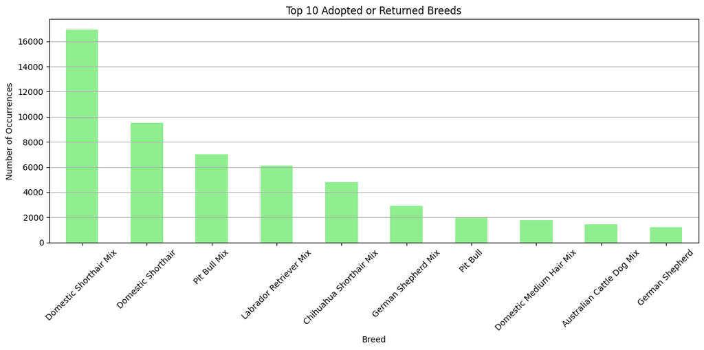

```python
# Filter the dataset to include only rows with Adoption or Return to Owner outcomes
positive_outcomes = df2[df2['Outcome_Type'].isin(['Adoption', 'Return to Owner'])]

# Group the data by breed and count the number of occurrences for each breed
breed_counts = positive_outcomes['Breed'].value_counts()

# Select the top N breeds (you can change N based on your preference)
top_n = 10
top_breeds = breed_counts.head(top_n)

# Create a bar chart to visualize the top adopted or returned breeds
plt.figure(figsize=(12, 6))
top_breeds.plot(kind='bar', color='lightgreen')
plt.title(f'Top {top_n} Adopted or Returned Breeds')
plt.xlabel('Breed')
plt.ylabel('Number of Occurrences')
plt.xticks(rotation=45)  # Rotate x-axis labels for better readability
plt.grid(axis='y')  # Add grid lines on the y-axis

# Show the chart
plt.tight_layout()
plt.show()
```

### Most Adopted or Returned Animal Types

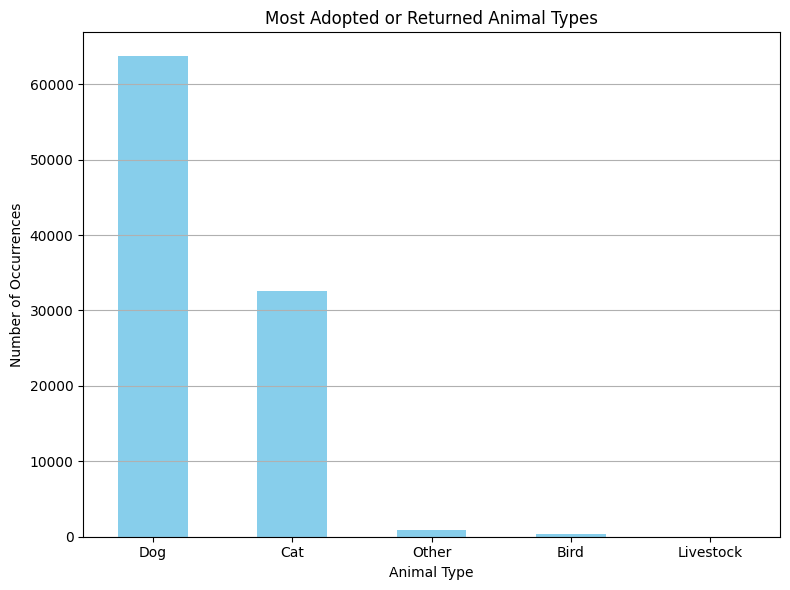

```python
# Filter the dataset to include only rows with Adoption or Return to Owner outcomes
positive_outcomes = df2[df2['Outcome_Type'].isin(['Adoption', 'Return to Owner'])]

# Group the data by animal type and count the number of occurrences for each type
animal_type_counts = positive_outcomes['Animal_Type'].value_counts()

# Create a bar chart to visualize the most adopted or returned animal types
plt.figure(figsize=(8, 6))
animal_type_counts.plot(kind='bar', color='skyblue')
plt.title('Most Adopted or Returned Animal Types')
plt.xlabel('Animal Type')
plt.ylabel('Number of Occurrences')
plt.xticks(rotation=0)  # Remove x-axis rotation for better readability
plt.grid(axis='y')  # Add grid lines on the y-axis

# Show the chart
plt.tight_layout()
plt.show()
```

### Top 15 Adopted or Returned Breeds by Animal Type

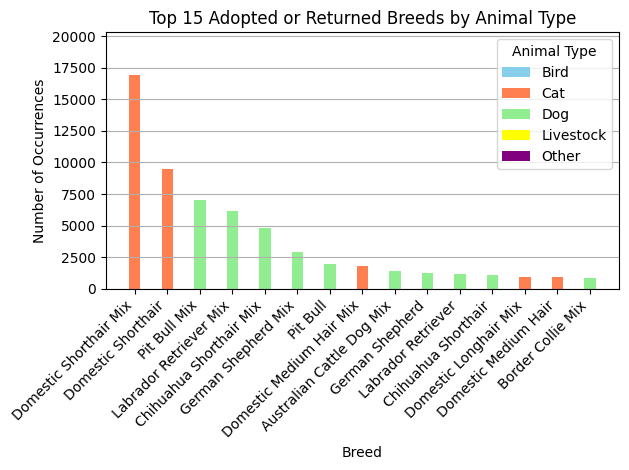

```python
# Filter the dataset to include only rows with Adoption or Return to Owner outcomes
positive_outcomes = df2[df2['Outcome_Type'].isin(['Adoption', 'Return to Owner'])]

# Group the data by both breed and animal type and count the number of occurrences for each combination
breed_type_counts = positive_outcomes.groupby(['Breed', 'Animal_Type']).size().unstack(fill_value=0)

# Select the top 15 breeds (you can change this number based on your preference)
top_n = 15
top_breeds = breed_type_counts.sum(axis=1).sort_values(ascending=False).head(top_n)

# Create a grouped bar plot to visualize the adopted or returned breeds by animal type
plt.figure(figsize=(14, 6))
ind = np.arange(len(top_breeds))
width = 0.35

# Define colors for each animal type
colors = ['skyblue', 'coral', 'lightgreen', 'yellow', 'purple']

fig, ax = plt.subplots()

# Initialize the bar plot
bottom = np.zeros(len(top_breeds))

for i, animal_type in enumerate(breed_type_counts.columns):
    counts = breed_type_counts[animal_type].loc[top_breeds.index]
    ax.bar(ind, counts, width, label=animal_type, bottom=bottom, color=colors[i])
    bottom += counts

ax.set_title(f'Top {top_n} Adopted or Returned Breeds by Animal Type')
ax.set_xlabel('Breed')
ax.set_ylabel('Number of Occurrences')
ax.set_xticks(ind)
ax.set_xticklabels(top_breeds.index, rotation=45, ha='right')  # Rotate x-axis labels for better readability
ax.legend(title='Animal Type')

plt.ylim(0, max(bottom) * 1.2)
plt.grid(axis='y')

# Show the chart
plt.tight_layout()
plt.show()
```

### Austin_Animal_Center_Stray_Map

```python
from IPython.display import display

# Create a base map centered on a location (you can adjust the coordinates and zoom level)
m = folium.Map(location=[30.2672, -97.7431], zoom_start=11)

for index, row in df_map.iterrows():
    if not pd.isna(row['Latitude']) and not pd.isna(row['Longitude']):
        folium.Marker(
            location=[row['Latitude'], row['Longitude']],
            tooltip='Animal Found Here',
        ).add_to(m)

# Display the map in the Jupyter Notebook
display(m)
```

Make this Notebook Trusted to load map: File -> Trust Notebook

[interactive chart not shown]

### Heatmap of Locations of Stray Animals Found

```python
from folium.plugins import HeatMap

location_counts = df_map.groupby(['Latitude', 'Longitude']).size().reset_index(name='Count')

# Create a base map centered at a suitable location
m = folium.Map(location=[30.2672, -97.7431], zoom_start=11)

# Create a HeatMap layer based on the location counts
heat_data = [[ row['Latitude'], row['Longitude'], row['Count']] for index, row in location_counts.iterrows()]
HeatMap(heat_data).add_to(m)

# Display the map in the Jupyter Notebook
display(m)
```

Make this Notebook Trusted to load map: File -> Trust Notebook

[interactive chart not shown]

The heatmap generated using the Folium library serves as a valuable tool in our project for visualizing and understanding the geographical distribution of stray animals in the Austin area. It provides a clear and intuitive representation of hotspots where stray animal activity is concentrated. This information is immensely useful for our project in the following ways:

1. **Efficient Resource Allocation:** By identifying these hotspots, animal shelters and rescue teams can strategically allocate resources such as staff and supplies to areas with the highest need, improving the efficiency of rescue and care operations.
2. **Targeted Outreach:** The heatmap allows us to focus on specific neighborhoods or regions where stray animals are more prevalent. This, in turn, enables us to design targeted outreach and awareness campaigns to encourage responsible pet ownership and promote adoption.
3. **Public Engagement:** Sharing this heatmap with the community can foster greater public engagement and collaboration. It can motivate local residents to get involved in supporting animal welfare efforts in their own neighborhoods.
4. **Data-Driven Decision-Making:** The heatmap provides visual evidence of the areas with the greatest demand for animal shelter services. This data-driven approach guides decision-making and resource management, ultimately leading to more effective shelter operations and improved animal well-being.

Incorporating this heatmap visualization in our project report enhances our ability to communicate the significance of geographical insights and their practical applications in optimizing animal shelter operations and community engagement.

### Possible Sources of Bias

- **Time Period Bias:** Data collected during specific time periods may not accurately reflect long-term trends. For example, seasonal variations or changes in shelter policies over time can introduce bias.
- **Missing Data Bias:** If certain records are missing or incomplete, it can lead to bias in the analysis. Bias may occur if missing data is not handled properly during preprocessing.
- **Reporting Bias:** Biases can arise from the way outcomes are reported. For example, if there are discrepancies in how outcomes like adoptions or euthanasia are documented, it can affect the results.
- **Human Bias:** The decisions made by shelter staff and volunteers can introduce bias. For instance, subjective judgments about an animal's temperament or health status can influence outcomes.
- **Geographical Bias:** Geographical bias can occur if certain areas are more likely to report stray animals or if rescue efforts are concentrated in specific regions.

## 6. Conclusion

By using data-driven insights, shelters can make better decisions about where to put resources, increase adoptions, and make sure the animals in our care are happy and healthy. This project has the potential to make a positive impact on the lives of animals and the efficiency of our shelter operations.

## 7. Future Work

In the future, we can expand our project by developing predictive models. These models could help us foresee the number of animals coming into the shelter, making it easier to plan and allocate resources efficiently. Additionally, we can work on models to identify which types of animals are more likely to find loving homes, enabling us to focus our efforts where they're needed most. These steps will further enhance our ability to improve animal welfare and make our shelter operations even more effective.

### Acknowledgments

We would like to express our gratitude to the Austin Animal Center for providing us with access to their valuable data. We also acknowledge the dedication of the shelter staff and volunteers who work tirelessly to improve the lives of animals in their care. This project wouldn't have been possible without their contributions and commitment to animal welfare.

Finally, we thank our mentors and advisors for their guidance and insights, which enriched our project and contributed to its positive outcomes.